# Cross Validation of ML algorithms with simple data analysis

```python
import warnings
warnings.filterwarnings('ignore')
import numpy as np
from matplotlib import pyplot as plt
import matplotlib
from matplotlib import colors as mcolors
from sklearn.ensemble.partial_dependence import partial_dependence, plot_partial_dependence
import pandas as pd
import sklearn as sk
from xgboost import XGBClassifier
from sklearn.preprocessing.imputation import Imputer
from sklearn.preprocessing import StandardScaler
from sklearn.model_selection import train_test_split
from sklearn.model_selection import KFold
from sklearn.model_selection import cross_val_score
from sklearn.model_selection import GridSearchCV
from sklearn.metrics import classification_report
from sklearn.metrics import confusion_matrix
from sklearn.metrics import accuracy_score
from sklearn.pipeline import Pipeline
from sklearn.linear_model import LogisticRegression
from sklearn.tree import DecisionTreeClassifier
from sklearn.neighbors import KNeighborsClassifier
from sklearn.discriminant_analysis import LinearDiscriminantAnalysis
from sklearn.naive_bayes import GaussianNB
from sklearn.svm import SVC
from sklearn.ensemble import AdaBoostClassifier
from sklearn.ensemble import GradientBoostingClassifier
from sklearn.ensemble import RandomForestClassifier
from sklearn.ensemble import ExtraTreesClassifier
import plotly.offline as py
py.init_notebook_mode(connected=True)
import plotly.graph_objs as go
import plotly.tools as tls
%matplotlib inline
```

# Load and check training dataset

```python
dataset = pd.read_csv("C:\\Users\\Amadeusz\\Downloads\\all\\training_set.csv")
dataset.head()
#
# mjd - the time in Modified Julian Date (MJD) of the observation.
#       Can be read as days since November 17, 1858. Can be converted to Unix epoch time with the formula
#       unix_time = (MJD−40587)×86400. Float64
#
# passband - The specific LSST passband integer, such that u, g, r, i, z, Y = 0, 1, 2, 3, 4, 5 in which it was viewed. Int8
#
# flux - the measured flux (brightness) in the passband of observation as listed in the passband column.
#        These values have already been corrected for dust extinction (mwebv), though heavily extincted objects
#        will have larger uncertainties (flux_err) in spite of the correction. Float32
#
# flux_err -  the uncertainty on the measurement of the flux listed above. Float32
#
# detected - If 1, the object's brightness is significantly different at the 3-sigma level
#           relative to the reference template. Only objects with at least 2 detections are included in the dataset. Boolean
```

|  | object_id | mjd | passband | flux | flux_err | detected |
| --- | --- | --- | --- | --- | --- | --- |
| 0 | 615 | 59750.4229 | 2 | -544.810303 | 3.622952 | 1 |
| 1 | 615 | 59750.4306 | 1 | -816.434326 | 5.553370 | 1 |
| 2 | 615 | 59750.4383 | 3 | -471.385529 | 3.801213 | 1 |
| 3 | 615 | 59750.4450 | 4 | -388.984985 | 11.395031 | 1 |
| 4 | 615 | 59752.4070 | 2 | -681.858887 | 4.041204 | 1 |

```python
dataset.describe()
# "detected" column is binary (contains 0 or 1 values)
```

|  | object_id | mjd | passband | flux | flux_err | detected |
| --- | --- | --- | --- | --- | --- | --- |
| count | 1.421705e+06 | 1.421705e+06 | 1.421705e+06 | 1.421705e+06 | 1.421705e+06 | 1.421705e+06 |
| mean | 3.392608e+07 | 6.017921e+04 | 2.783108e+00 | 2.468855e+01 | 2.548932e+01 | 1.666168e-01 |
| std | 4.258439e+07 | 3.092379e+02 | 1.703946e+00 | 3.684506e+03 | 3.814492e+03 | 3.726336e-01 |
| min | 6.150000e+02 | 5.958003e+04 | 0.000000e+00 | -1.149388e+06 | 4.637530e-01 | 0.000000e+00 |
| 25% | 1.843400e+05 | 5.989905e+04 | 1.000000e+00 | -2.789418e+00 | 2.118670e+00 | 0.000000e+00 |
| 50% | 4.548783e+06 | 6.019331e+04 | 3.000000e+00 | 7.331990e-01 | 4.708105e+00 | 0.000000e+00 |
| 75% | 6.796280e+07 | 6.048722e+04 | 4.000000e+00 | 8.830932e+00 | 1.297371e+01 | 0.000000e+00 |
| max | 1.307798e+08 | 6.067436e+04 | 5.000000e+00 | 2.432809e+06 | 2.234069e+06 | 1.000000e+00 |

```python
# extract each passband
for key, val in {'u': 0, 'g': 1, 'r': 2, 'i': 3, 'z': 4, 'y': 5}.items():
    dataset[key] = (dataset['passband']-val).apply(np.bool).apply(np.logical_not).apply(np.int)
dataset.head()
```

|  | object_id | mjd | passband | flux | flux_err | detected | r | i | z | y | u | g |
| --- | --- | --- | --- | --- | --- | --- | --- | --- | --- | --- | --- | --- |
| 0 | 615 | 59750.4229 | 2 | -544.810303 | 3.622952 | 1 | 1 | 0 | 0 | 0 | 0 | 0 |
| 1 | 615 | 59750.4306 | 1 | -816.434326 | 5.553370 | 1 | 0 | 0 | 0 | 0 | 0 | 1 |
| 2 | 615 | 59750.4383 | 3 | -471.385529 | 3.801213 | 1 | 0 | 1 | 0 | 0 | 0 | 0 |
| 3 | 615 | 59750.4450 | 4 | -388.984985 | 11.395031 | 1 | 0 | 0 | 1 | 0 | 0 | 0 |
| 4 | 615 | 59752.4070 | 2 | -681.858887 | 4.041204 | 1 | 1 | 0 | 0 | 0 | 0 | 0 |

# Convert Modified Julian Date to readable format

```python
# convert mjd to unix time
unix_time = (dataset['mjd']-40587)*86400
#convert unix time to readable format
time_ = pd.to_datetime(unix_time, unit='ms')
```

```python
# information extraction from modified julian date
# dataset["year"] = time_.dt.year
# dataset["month"] = time_.dt.month
# dataset["day"] = time_.dt.day
# dataset["week"] = time_.dt.week
# dataset["dayofweek"] = time_.dt.dayofweek
dataset["hour"] = time_.dt.hour
dataset["minute"] = time_.dt.minute
dataset["second"] = time_.dt.second
dataset["ms"] = time_.dt.microsecond
# dataset = dataset.drop(["mjd"], axis=1)
dataset.head()
```

|  | object_id | mjd | passband | flux | flux_err | detected | r | i | z | y | u | g | hour | minute | second | ms |
| --- | --- | --- | --- | --- | --- | --- | --- | --- | --- | --- | --- | --- | --- | --- | --- | --- |
| 0 | 615 | 59750.4229 | 2 | -544.810303 | 3.622952 | 1 | 1 | 0 | 0 | 0 | 0 | 0 | 3 | 55 | 19 | 738560 |
| 1 | 615 | 59750.4306 | 1 | -816.434326 | 5.553370 | 1 | 0 | 0 | 0 | 0 | 0 | 1 | 3 | 55 | 20 | 403840 |
| 2 | 615 | 59750.4383 | 3 | -471.385529 | 3.801213 | 1 | 0 | 1 | 0 | 0 | 0 | 0 | 3 | 55 | 21 | 69120 |
| 3 | 615 | 59750.4450 | 4 | -388.984985 | 11.395031 | 1 | 0 | 0 | 1 | 0 | 0 | 0 | 3 | 55 | 21 | 648000 |
| 4 | 615 | 59752.4070 | 2 | -681.858887 | 4.041204 | 1 | 1 | 0 | 0 | 0 | 0 | 0 | 3 | 58 | 11 | 164800 |

# Empty value veryfication

```python
# check if there is any null value
dataset.isnull().sum()
```

```
object_id    0
mjd          0
passband     0
flux         0
flux_err     0
detected     0
r            0
i            0
z            0
y            0
u            0
g            0
hour         0
minute       0
second       0
ms           0
dtype: int64
```

# Feature engineering

```python
import gc
gc.enable()
dataset['flux_ratio_sq'] = np.power(dataset['flux'] / dataset['flux_err'], 2.0)
dataset['flux_by_flux_ratio_sq'] = dataset['flux'] * dataset['flux_ratio_sq']

aggs = {
    'mjd': ['min', 'max', 'size'],
    'passband': ['min', 'max', 'mean', 'median', 'std'],
    'flux': ['min', 'max', 'mean', 'median', 'std','skew'],
    'flux_err': ['min', 'max', 'mean', 'median', 'std','skew'],
    'detected': ['mean'],
    'flux_ratio_sq':['sum','skew'],
    'flux_by_flux_ratio_sq':['sum','skew'],
    'r': ['sum'],
    'g': ['sum'],
    'i': ['sum'],
    'u': ['sum'],
    'z': ['sum'],
    'y': ['sum'],
#     'month': ['min', 'max', 'median'],
#     'day': ['min', 'max', 'median'],
#     'week': ['min', 'max', 'median'],
#     'dayofweek': ['min', 'max', 'median'],
    'hour': ['min', 'max', 'median'],
    'minute': ['min', 'max', 'median'],
    'second': ['min', 'max', 'median'],
    'ms': ['min', 'max', 'median'],
}

agg_train = dataset.groupby('object_id').agg(aggs)
new_columns = [k + '_' + agg for k in aggs.keys() for agg in aggs[k]]
agg_train.columns = new_columns
# agg_train['month_diff'] = agg_train['month_max'] - agg_train['month_min']
# agg_train['day_diff'] = agg_train['day_max'] - agg_train['day_min']
# agg_train['week_diff'] = agg_train['week_max'] - agg_train['week_min']
# agg_train['dayofweek_diff'] = agg_train['dayofweek_max'] - agg_train['dayofweek_min']
agg_train['hour_diff'] = agg_train['hour_max'] - agg_train['hour_min']
agg_train['minute_diff'] = agg_train['minute_max'] - agg_train['minute_min']
agg_train['second_diff'] = agg_train['second_max'] - agg_train['second_min']
agg_train['ms_diff'] = agg_train['ms_max'] - agg_train['ms_min']
agg_train['mjd_diff'] = agg_train['mjd_max'] - agg_train['mjd_min']
agg_train['flux_diff'] = agg_train['flux_max'] - agg_train['flux_min']
agg_train['flux_dif2'] = (agg_train['flux_max'] - agg_train['flux_min']) / agg_train['flux_mean']
agg_train['flux_w_mean'] = agg_train['flux_by_flux_ratio_sq_sum'] / agg_train['flux_ratio_sq_sum']
agg_train['flux_dif3'] = (agg_train['flux_max'] - agg_train['flux_min']) / agg_train['flux_w_mean']

del agg_train['mjd_max'], agg_train['mjd_min']
# del agg_train['month_max'], agg_train['month_min']
# del agg_train['day_max'], agg_train['day_min']
# del agg_train['week_max'], agg_train['week_min']
# del agg_train['dayofweek_max'], agg_train['dayofweek_min']
del agg_train['hour_max'], agg_train['hour_min']
del agg_train['minute_max'], agg_train['minute_min']
del agg_train['second_max'], agg_train['second_min']
del agg_train['ms_max'], agg_train['ms_min']
agg_train.head()

del dataset
gc.collect()
```

```
6940
```

```python
agg_train.head()
```

| object_id | flux_min | flux_max | flux_mean | flux_median | flux_std | flux_skew | second_median | g_sum | detected_mean | hour_median | ... | flux_ratio_sq_skew | hour_diff | minute_diff | second_diff | ms_diff | mjd_diff | flux_diff | flux_dif2 | flux_w_mean | flux_dif3 |
| --- | --- | --- | --- | --- | --- | --- | --- | --- | --- | --- | --- | --- | --- | --- | --- | --- | --- | --- | --- | --- | --- |
| 615 | -1100.440063 | 660.626343 | -123.096998 | -89.477524 | 394.109851 | -0.349540 | 30.0 | 58 | 0.946023 | 13.0 | ... | 0.812722 | 23 | 59 | 59 | 994240 | 873.7903 | 1761.066406 | -14.306331 | -327.742307 | -5.373326 |
| 713 | -14.735178 | 14.770886 | -1.423351 | -0.873033 | 6.471144 | 0.014989 | 27.0 | 56 | 0.171429 | 7.0 | ... | 3.439423 | 23 | 59 | 59 | 983680 | 848.8198 | 29.506064 | -20.730002 | -4.884564 | -6.040676 |
| 730 | -19.159811 | 47.310059 | 2.267434 | 0.409172 | 8.022239 | 3.177854 | 32.0 | 52 | 0.069697 | 7.0 | ... | 5.480405 | 23 | 59 | 59 | 996480 | 853.8455 | 66.469870 | 29.315018 | 25.373110 | 2.619697 |
| 745 | -15.494463 | 220.795212 | 8.909206 | 1.035895 | 27.558208 | 4.979826 | 26.0 | 56 | 0.173789 | 13.0 | ... | 9.611274 | 23 | 59 | 59 | 995520 | 853.7060 | 236.289675 | 26.521968 | 152.835617 | 1.546038 |
| 1124 | -16.543753 | 143.600189 | 7.145702 | 1.141288 | 20.051722 | 4.406298 | 30.0 | 58 | 0.173295 | 13.0 | ... | 7.868462 | 23 | 59 | 59 | 994240 | 873.7903 | 160.143942 | 22.411225 | 87.856390 | 1.822792 |

5 rows × 42 columns

# Load training meta_dataset

```python
meta_dataset = pd.read_csv('C:\\Users\\Amadeusz\\Downloads\\all\\training_set_metadata.csv')
column_names = {6: "class_6", 15: "class_15", 16: "class_16", 42: "class_42", 52: "class_52", 53: "class_53",
                62: "class_62", 64: "class_64", 65: "class_65", 67: "class_67", 88: "class_88", 90: "class_90",
                92: "class_92", 95: "class_95"}
meta_dataset["target"] = list(map(lambda name: column_names[name], meta_dataset["target"]))
meta_dataset.head()

# ra - right ascension, sky coordinate: co-longitude in degrees. Float32
#
# decl - declination, sky coordinate: co-latitude in degrees. Float32
#
# gal_l - galactic longitude in degrees. Float32
#
# gal_b - galactic latitude in degrees. Float32
#
# ddf - A flag to identify the object as coming from the DDF survey area
#       (with value DDF = 1 for the DDF, DDF = 0 for the WFD survey).
#       Note that while the DDF fields are contained within the full WFD survey area, the DDF fluxes have
#       significantly smaller uncertainties. Boolean
#
# hostgal_specz - the spectroscopic redshift of the source. This is an extremely accurate measure of redshift,
#                 available for the training set and a small fraction of the test set. Float32
#
# hostgal_photoz - The photometric redshift of the host galaxy of the astronomical source.
#                  While this is meant to be a proxy for hostgal_specz, there can be large differences between
#                  the two and should be regarded as a far less accurate version of hostgal_specz. Float32
#
# hostgal_photoz_err - The uncertainty on the hostgal_photoz based on LSST survey projections. Float32
#
# distmod - The distance to the source calculated from hostgal_photoz and using general relativity. Float32
#
# mwebv - MW E(B-V). this ‘extinction’ of light is a property of the Milky Way (MW) dust along the line of sight
#         to the astronomical source, and is thus a function of the sky coordinates of the source ra, decl.
#       This is used to determine a passband dependent dimming and redenning of light from astronomical sources
#       as described in subsection 2.1, and based on the Schlafly et al. (2011) and Schlegel et al. (1998) dust models. Float32
```

|  | object_id | ra | decl | gal_l | gal_b | ddf | hostgal_specz | hostgal_photoz | hostgal_photoz_err | distmod | mwebv | target |
| --- | --- | --- | --- | --- | --- | --- | --- | --- | --- | --- | --- | --- |
| 0 | 615 | 349.046051 | -61.943836 | 320.796530 | -51.753706 | 1 | 0.0000 | 0.0000 | 0.0000 | NaN | 0.017 | class_92 |
| 1 | 713 | 53.085938 | -27.784405 | 223.525509 | -54.460748 | 1 | 1.8181 | 1.6267 | 0.2552 | 45.4063 | 0.007 | class_88 |
| 2 | 730 | 33.574219 | -6.579593 | 170.455585 | -61.548219 | 1 | 0.2320 | 0.2262 | 0.0157 | 40.2561 | 0.021 | class_42 |
| 3 | 745 | 0.189873 | -45.586655 | 328.254458 | -68.969298 | 1 | 0.3037 | 0.2813 | 1.1523 | 40.7951 | 0.007 | class_90 |
| 4 | 1124 | 352.711273 | -63.823658 | 316.922299 | -51.059403 | 1 | 0.1934 | 0.2415 | 0.0176 | 40.4166 | 0.024 | class_90 |

```python
# from description -> NaN values in "distmod" teels us that this object is in our galaxy (no redshift provided/hostgal),
# distmod is calculated from redshift via general relativity
# create new features (in_our_galaxy)
meta_dataset['in_our_galaxy'] = meta_dataset['distmod'].apply(np.isnan).astype(int)
meta_dataset.head()
```

|  | object_id | ra | decl | gal_l | gal_b | ddf | hostgal_specz | hostgal_photoz | hostgal_photoz_err | distmod | mwebv | target | in_our_galaxy |
| --- | --- | --- | --- | --- | --- | --- | --- | --- | --- | --- | --- | --- | --- |
| 0 | 615 | 349.046051 | -61.943836 | 320.796530 | -51.753706 | 1 | 0.0000 | 0.0000 | 0.0000 | NaN | 0.017 | class_92 | 1 |
| 1 | 713 | 53.085938 | -27.784405 | 223.525509 | -54.460748 | 1 | 1.8181 | 1.6267 | 0.2552 | 45.4063 | 0.007 | class_88 | 0 |
| 2 | 730 | 33.574219 | -6.579593 | 170.455585 | -61.548219 | 1 | 0.2320 | 0.2262 | 0.0157 | 40.2561 | 0.021 | class_42 | 0 |
| 3 | 745 | 0.189873 | -45.586655 | 328.254458 | -68.969298 | 1 | 0.3037 | 0.2813 | 1.1523 | 40.7951 | 0.007 | class_90 | 0 |
| 4 | 1124 | 352.711273 | -63.823658 | 316.922299 | -51.059403 | 1 | 0.1934 | 0.2415 | 0.0176 | 40.4166 | 0.024 | class_90 | 0 |

# Empty value veryfication

```python
meta_dataset.isnull().sum()
```

```
object_id                0
ra                       0
decl                     0
gal_l                    0
gal_b                    0
ddf                      0
hostgal_specz            0
hostgal_photoz           0
hostgal_photoz_err       0
distmod               2325
mwebv                    0
target                   0
in_our_galaxy            0
dtype: int64
```

```python
print("distmod missing data in %: {}".format(meta_dataset.isnull().sum()[-4]*100/meta_dataset.shape[0]))
```

```
distmod missing data in %: 29.625382262996943
```

```python
# put 0 instead of NaN in distmod (in that way we can store distance for objects out of our galaxy)
meta_dataset = meta_dataset.fillna(0)
meta_dataset.head()
```

|  | object_id | ra | decl | gal_l | gal_b | ddf | hostgal_specz | hostgal_photoz | hostgal_photoz_err | distmod | mwebv | target | in_our_galaxy |
| --- | --- | --- | --- | --- | --- | --- | --- | --- | --- | --- | --- | --- | --- |
| 0 | 615 | 349.046051 | -61.943836 | 320.796530 | -51.753706 | 1 | 0.0000 | 0.0000 | 0.0000 | 0.0000 | 0.017 | class_92 | 1 |
| 1 | 713 | 53.085938 | -27.784405 | 223.525509 | -54.460748 | 1 | 1.8181 | 1.6267 | 0.2552 | 45.4063 | 0.007 | class_88 | 0 |
| 2 | 730 | 33.574219 | -6.579593 | 170.455585 | -61.548219 | 1 | 0.2320 | 0.2262 | 0.0157 | 40.2561 | 0.021 | class_42 | 0 |
| 3 | 745 | 0.189873 | -45.586655 | 328.254458 | -68.969298 | 1 | 0.3037 | 0.2813 | 1.1523 | 40.7951 | 0.007 | class_90 | 0 |
| 4 | 1124 | 352.711273 | -63.823658 | 316.922299 | -51.059403 | 1 | 0.1934 | 0.2415 | 0.0176 | 40.4166 | 0.024 | class_90 | 0 |

```python
meta_dataset.isnull().sum()
```

```
object_id             0
ra                    0
decl                  0
gal_l                 0
gal_b                 0
ddf                   0
hostgal_specz         0
hostgal_photoz        0
hostgal_photoz_err    0
distmod               0
mwebv                 0
target                0
in_our_galaxy         0
dtype: int64
```

# Drop columns contains not valuable data

Training dataset contains hostgal_specz data, but test dataset (see next cells) do not.

```python
meta_dataset = meta_dataset.drop(['hostgal_specz'], axis=1)
meta_dataset.head()
```

|  | object_id | ra | decl | gal_l | gal_b | ddf | hostgal_photoz | hostgal_photoz_err | distmod | mwebv | target | in_our_galaxy |
| --- | --- | --- | --- | --- | --- | --- | --- | --- | --- | --- | --- | --- |
| 0 | 615 | 349.046051 | -61.943836 | 320.796530 | -51.753706 | 1 | 0.0000 | 0.0000 | 0.0000 | 0.017 | class_92 | 1 |
| 1 | 713 | 53.085938 | -27.784405 | 223.525509 | -54.460748 | 1 | 1.6267 | 0.2552 | 45.4063 | 0.007 | class_88 | 0 |
| 2 | 730 | 33.574219 | -6.579593 | 170.455585 | -61.548219 | 1 | 0.2262 | 0.0157 | 40.2561 | 0.021 | class_42 | 0 |
| 3 | 745 | 0.189873 | -45.586655 | 328.254458 | -68.969298 | 1 | 0.2813 | 1.1523 | 40.7951 | 0.007 | class_90 | 0 |
| 4 | 1124 | 352.711273 | -63.823658 | 316.922299 | -51.059403 | 1 | 0.2415 | 0.0176 | 40.4166 | 0.024 | class_90 | 0 |

# Plot objects on the sky map (per target class)

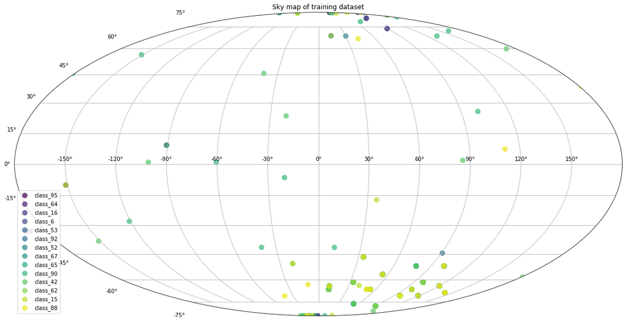

```python
fig = plt.figure(figsize=(20,15))
ax = fig.add_subplot(111, projection='mollweide')
data = meta_dataset[['ra', 'decl']]
data['target'] = meta_dataset['target']
category = list()
colors = plt.get_cmap('viridis').colors[::19]
for cat in set(meta_dataset['target']):
    category.append(data[data['target'].str.contains(cat)])
classes = list(set(meta_dataset['target']))
for cat, color, class_ in zip(category, colors, classes):
    ax.scatter(cat['ra'], cat['decl'], c=color, label=class_, edgecolors='none', s=100, alpha=0.7)
ax.legend()
ax.grid(True)
plt.title('Sky map of training dataset')
fig.savefig('sky_train_plot.pdf')
```

# How many objects of different type are in our galaxy?

We can clearly see that in our galaxy there are only specific type of objects (classes: 16, 53, 6, 65, 92).  
In test data we can cluster objects based on that.

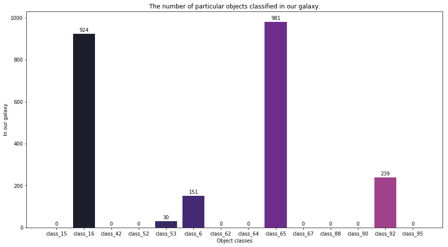

```python
colors = plt.get_cmap('magma').colors[::9]
data = meta_dataset[['target', 'in_our_galaxy']]
data['in_our_galaxy'] = data['in_our_galaxy']
data = data.groupby('target').sum()
fig = plt.figure(figsize=(15,8))
ax = fig.add_subplot(111)
ax.bar(data.index, data['in_our_galaxy'], color=colors, alpha=0.9)
ax.set_xlabel('Object classes')
ax.set_ylabel('In our galaxy')
plt.title('The number of particular objects classified in our galaxy.')
for i, rect in enumerate(data['in_our_galaxy']):
    ax.text(i, rect+10,rect, ha='center')
```

# Comparison of WFD and DDF objects detection number.

PLAsTiCC simulates the "Wide-Fast-Deep" Survey - the main LSST program, and the "Deep Drilling Fields" - a few small regions where LSST will get more observations for specialized scientific studies.

Which objects are in the WFD vs the DDF are specified by the ddf_bool column in the header (1 if in DDF, 0 otherwise).

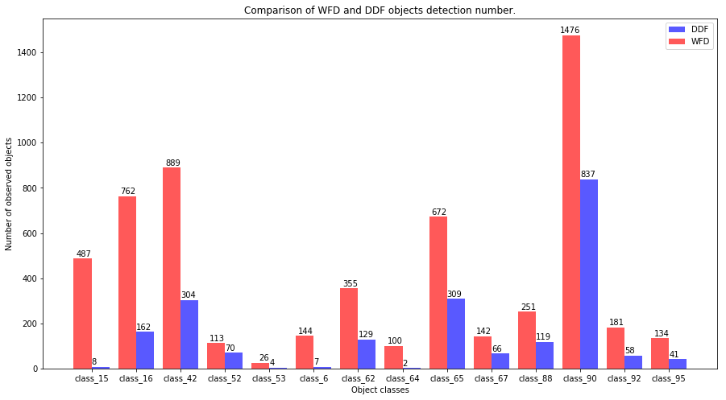

```python
colors = plt.get_cmap('magma').colors[::14]
fig = plt.figure(figsize=(15,8))
ax = fig.add_subplot(111)

data = meta_dataset[['target', 'ddf']]
data = data.groupby('target').sum()
p1 = ax.bar(np.arange(len(data.index))+0.2, data['ddf'], color='blue', alpha=0.65, width=0.4)
for i, rect in enumerate(data['ddf']):
    ax.text(i, rect+10,rect, ha='left')

data_2 = meta_dataset[['target', 'ddf']]
data_2['wfd'] = np.logical_xor(data_2['ddf'],1).astype(int)
data_2 = data_2.groupby('target').sum()
p2 = ax.bar(np.arange(len(data_2.index))-0.2, data_2['wfd'], color='red', alpha=0.65, width=0.4)
for i, rect in enumerate(data_2['wfd']):
    ax.text(i, rect+10,rect, ha='right')

ax.set_xticklabels(data.index)
ax.set_xticks(np.arange(len(data_2.index)))
ax.set_xlabel('Object classes')
ax.set_ylabel('Number of observed objects')
plt.title('Comparison of WFD and DDF objects detection number.')
ax.legend((p1,p2), ['DDF', 'WFD'])
```

```python
meta_test = pd.read_csv('C:\\Users\\Amadeusz\\Downloads\\all\\test_set_metadata.csv')
n_samples = meta_test.shape[0]
missing_values = meta_test.isnull().sum()
```

```python
for val, ind in zip(missing_values, missing_values.index):
    print("{} has {:2.2f}%  missing values.".format(ind, val*100/n_samples))
# hostgal_specz - missing 96%+ samples -> insufficient data for analysis and ML algorithms, need to be dropped
%xdel meta_test
```

```
object_id has 0.00%  missing values.
ra has 0.00%  missing values.
decl has 0.00%  missing values.
gal_l has 0.00%  missing values.
gal_b has 0.00%  missing values.
ddf has 0.00%  missing values.
hostgal_specz has 96.55%  missing values.
hostgal_photoz has 0.00%  missing values.
hostgal_photoz_err has 0.00%  missing values.
distmod has 11.18%  missing values.
mwebv has 0.00%  missing values.
```

# Merg training dataset and meta_dataset

```python
# training_dataset = pd.merge(dataset, meta_dataset) # without additional computed features
training_dataset = pd.merge(agg_train.reset_index(), meta_dataset) # with additional computed features
training_dataset.head()
```

|  | object_id | flux_min | flux_max | flux_mean | flux_median | flux_std | flux_skew | second_median | g_sum | detected_mean | ... | decl | gal_l | gal_b | ddf | hostgal_photoz | hostgal_photoz_err | distmod | mwebv | target | in_our_galaxy |
| --- | --- | --- | --- | --- | --- | --- | --- | --- | --- | --- | --- | --- | --- | --- | --- | --- | --- | --- | --- | --- | --- |
| 0 | 615 | -1100.440063 | 660.626343 | -123.096998 | -89.477524 | 394.109851 | -0.349540 | 30.0 | 58 | 0.946023 | ... | -61.943836 | 320.796530 | -51.753706 | 1 | 0.0000 | 0.0000 | 0.0000 | 0.017 | class_92 | 1 |
| 1 | 713 | -14.735178 | 14.770886 | -1.423351 | -0.873033 | 6.471144 | 0.014989 | 27.0 | 56 | 0.171429 | ... | -27.784405 | 223.525509 | -54.460748 | 1 | 1.6267 | 0.2552 | 45.4063 | 0.007 | class_88 | 0 |
| 2 | 730 | -19.159811 | 47.310059 | 2.267434 | 0.409172 | 8.022239 | 3.177854 | 32.0 | 52 | 0.069697 | ... | -6.579593 | 170.455585 | -61.548219 | 1 | 0.2262 | 0.0157 | 40.2561 | 0.021 | class_42 | 0 |
| 3 | 745 | -15.494463 | 220.795212 | 8.909206 | 1.035895 | 27.558208 | 4.979826 | 26.0 | 56 | 0.173789 | ... | -45.586655 | 328.254458 | -68.969298 | 1 | 0.2813 | 1.1523 | 40.7951 | 0.007 | class_90 | 0 |
| 4 | 1124 | -16.543753 | 143.600189 | 7.145702 | 1.141288 | 20.051722 | 4.406298 | 30.0 | 58 | 0.173295 | ... | -63.823658 | 316.922299 | -51.059403 | 1 | 0.2415 | 0.0176 | 40.4166 | 0.024 | class_90 | 0 |

5 rows × 54 columns

# The number of object detected in particular passband

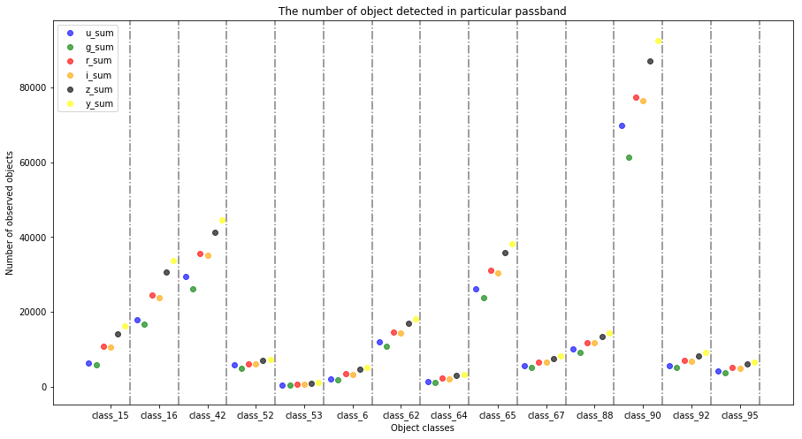

```python
fig = plt.figure(figsize=(15,8))
ax = fig.add_subplot(111)

data = training_dataset[['target', 'g_sum', 'r_sum', 'z_sum', 'u_sum', 'i_sum', 'y_sum']]
data = data.groupby('target').sum()
x = np.arange(len(data.index))
for i in range(len(data.index)):
    ax.axvline(x=i+0.4, linestyle='-.', color='grey')

p1 = ax.scatter(x-0.45, data['u_sum'], color='blue', alpha=0.65)
p2 = ax.scatter(x-0.3, data['g_sum'], color='green', alpha=0.65)
p3 = ax.scatter(x-0.15, data['r_sum'], color='red', alpha=0.65)
p4 = ax.scatter(x, data['i_sum'], color='orange', alpha=0.65)
p5 = ax.scatter(x+0.15, data['z_sum'], color='black', alpha=0.65)
p6 = ax.scatter(x+0.3, data['y_sum'], color='yellow', alpha=0.65)

ax.set_xticklabels(data.index)
ax.set_xticks(np.arange(len(data.index)))
ax.set_xlabel('Object classes')
ax.set_ylabel('Number of observed objects')
plt.title('The number of object detected in particular passband')
ax.legend((p1,p2, p3, p4, p5, p6), ['u_sum', 'g_sum', 'r_sum', 'i_sum', 'z_sum', 'y_sum'])
```

# Training data histograms

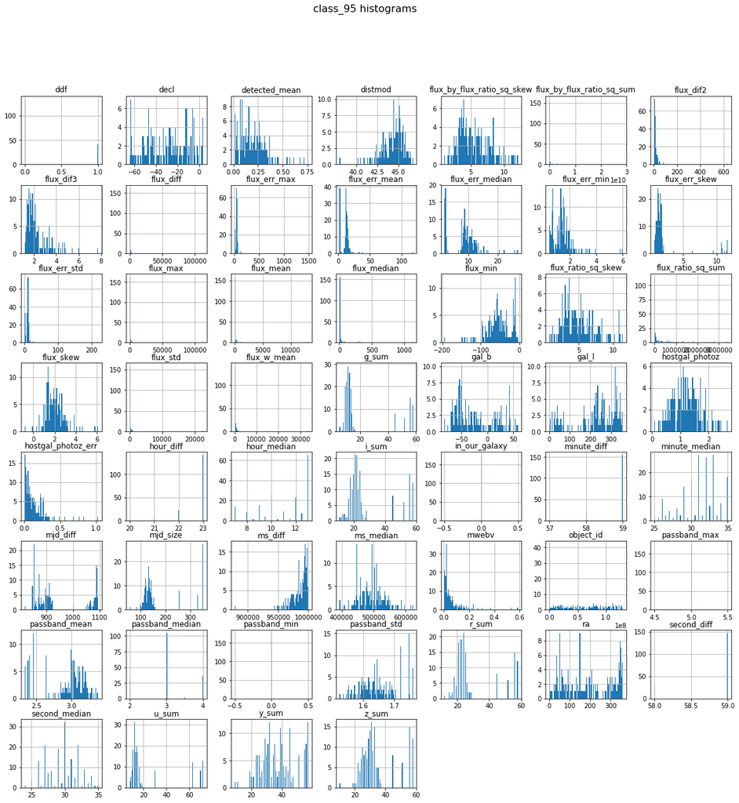

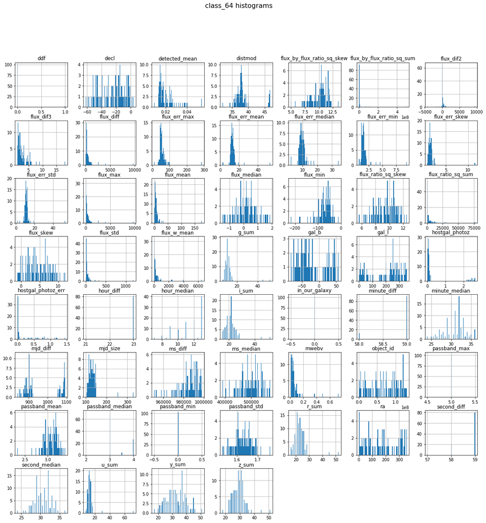

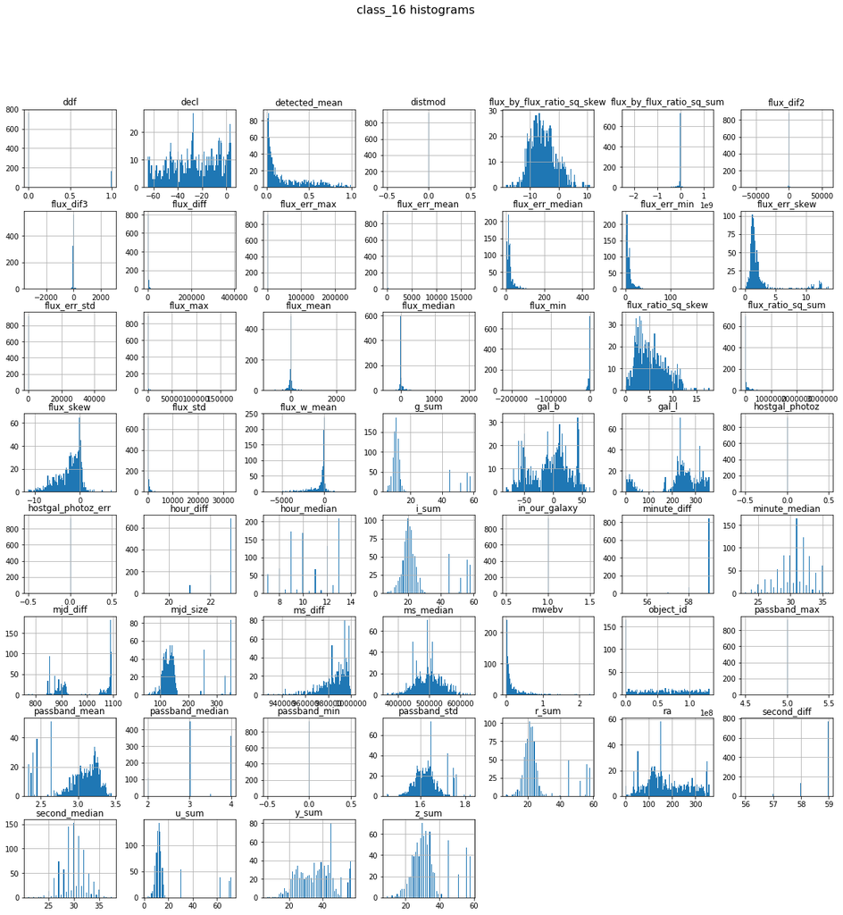

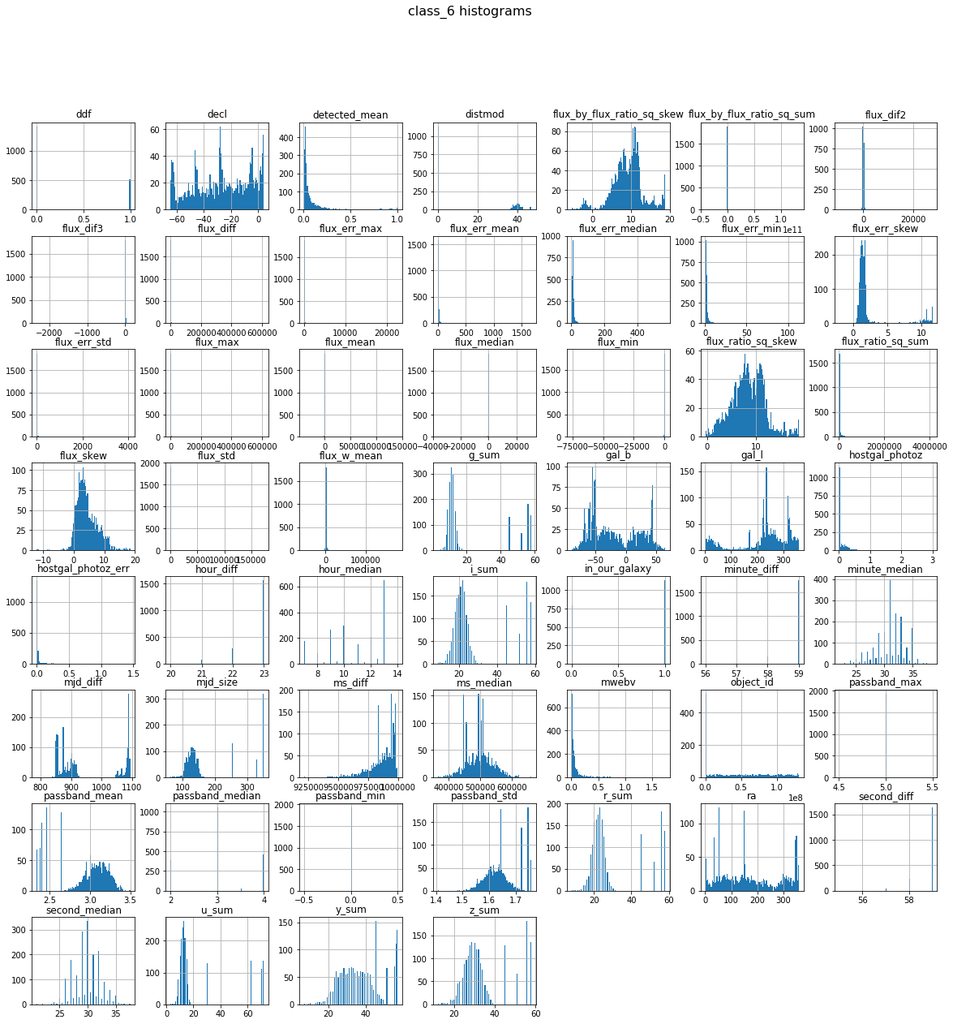

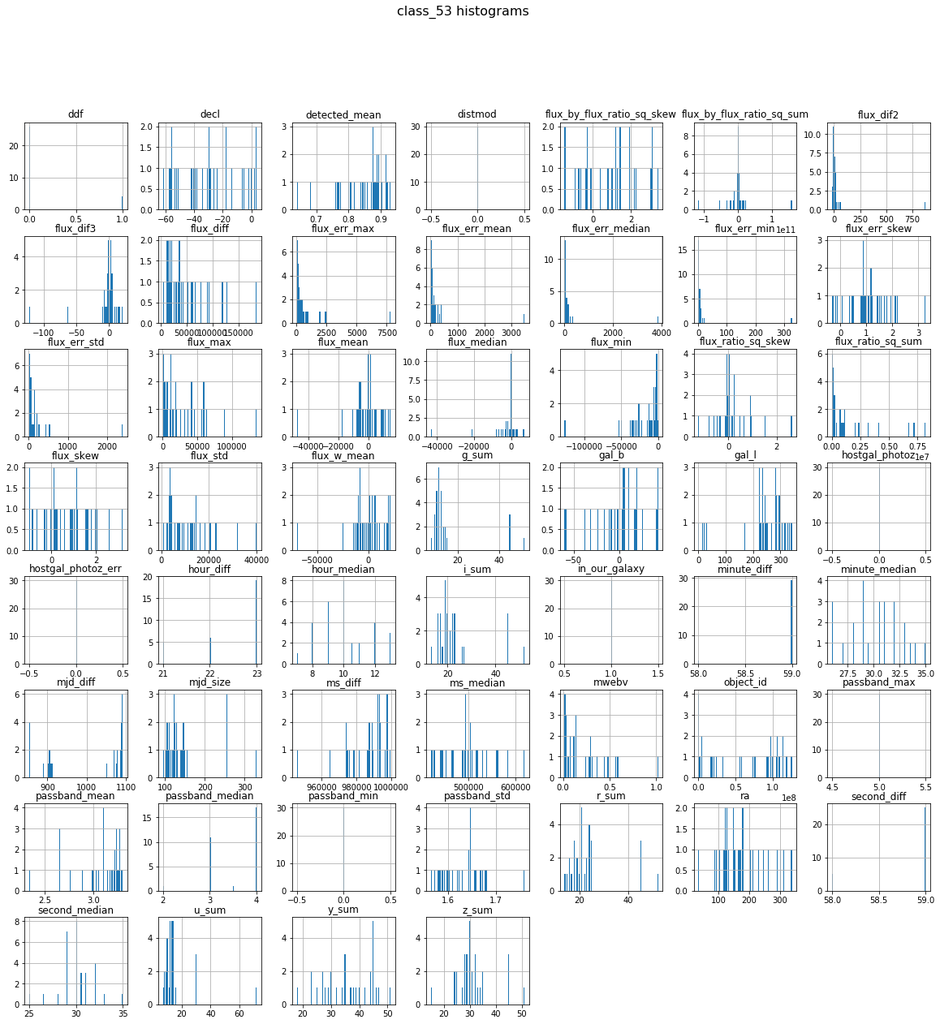

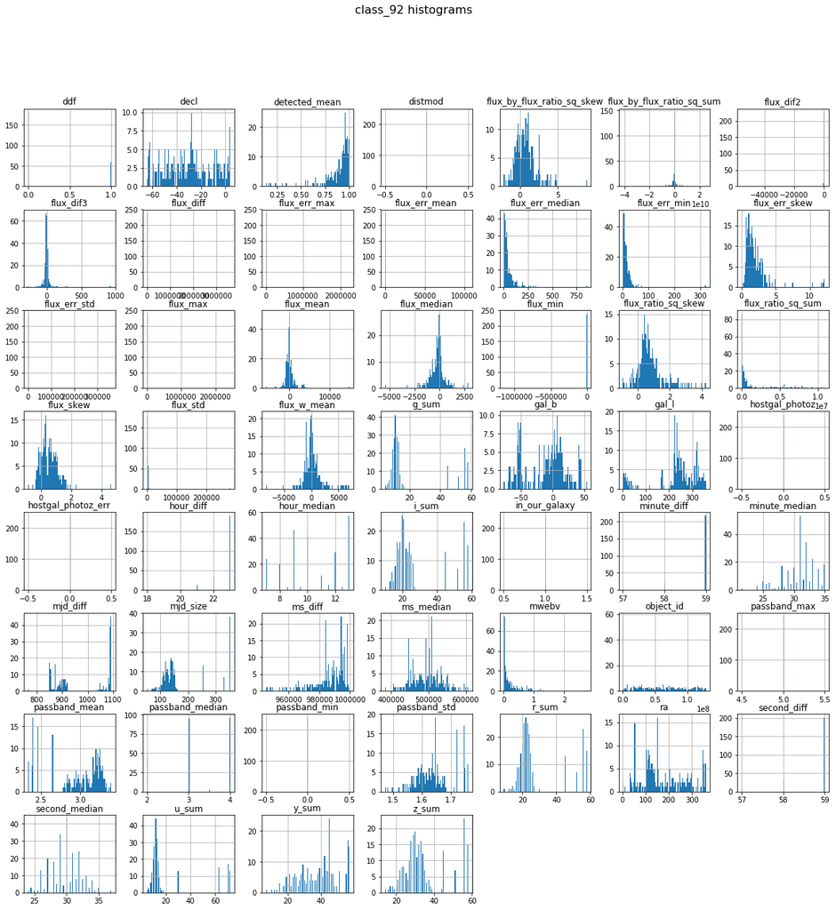

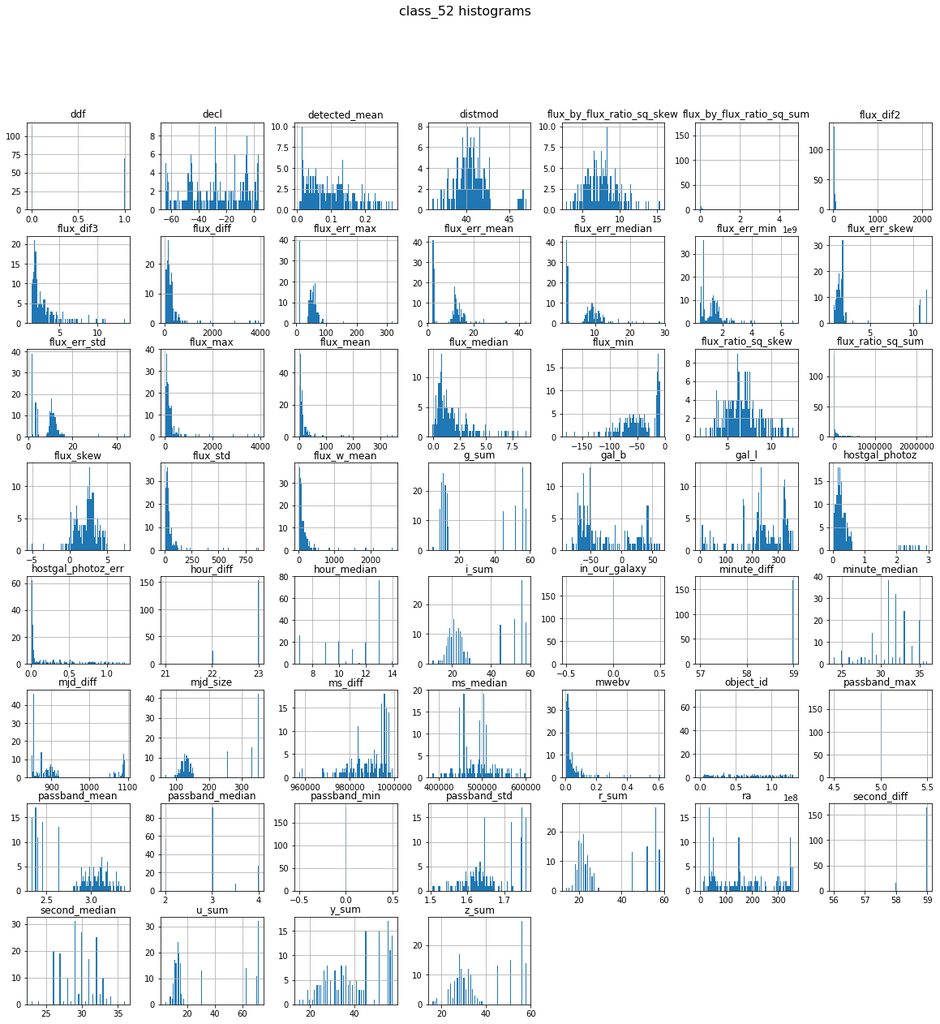

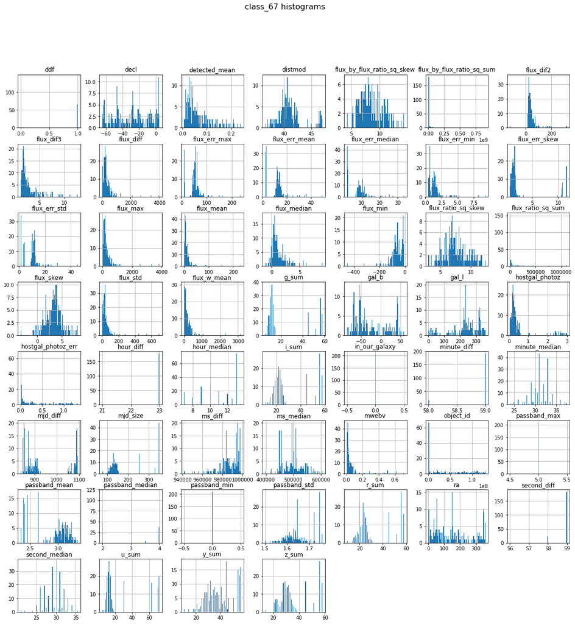

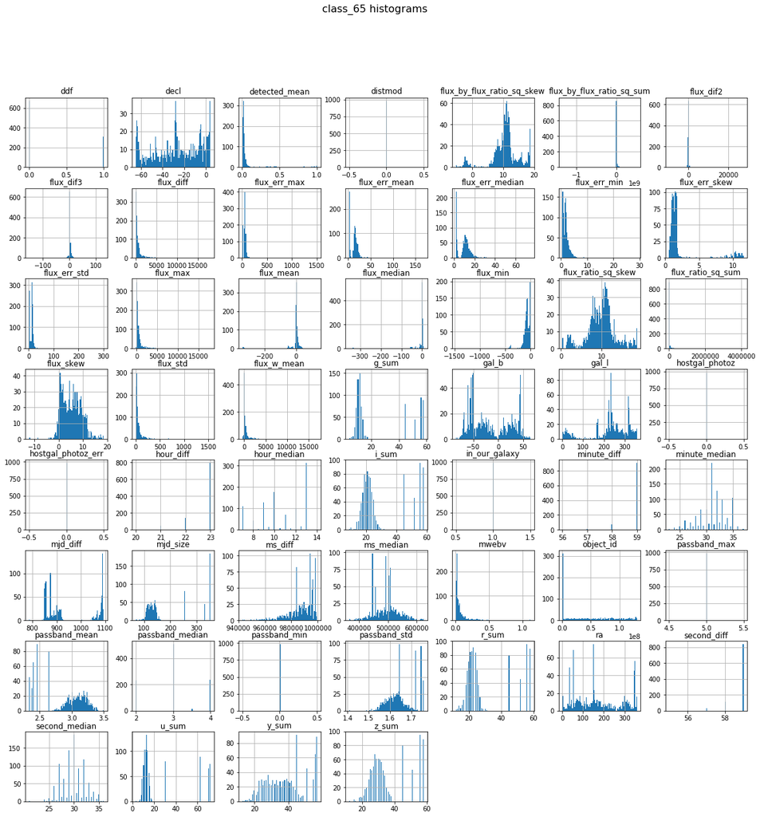

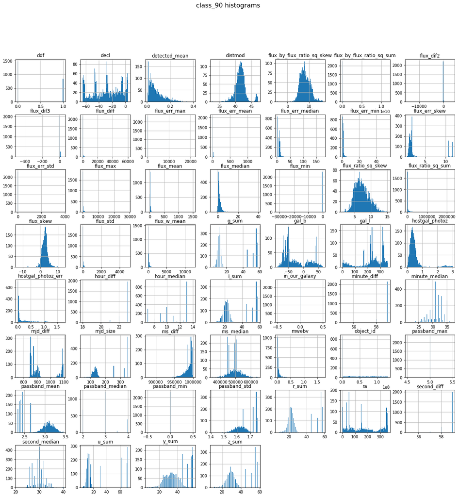

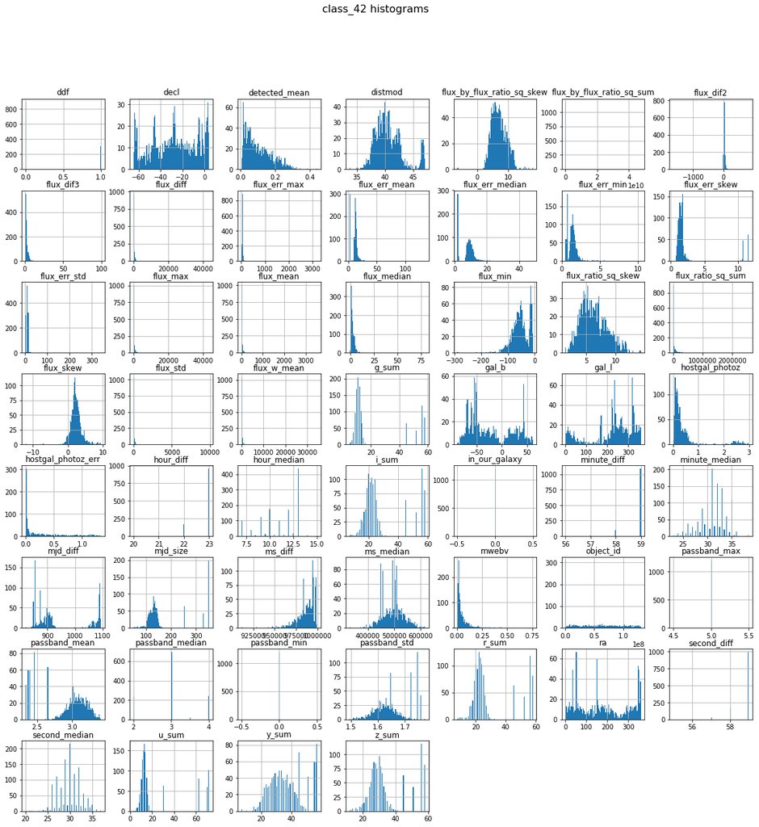

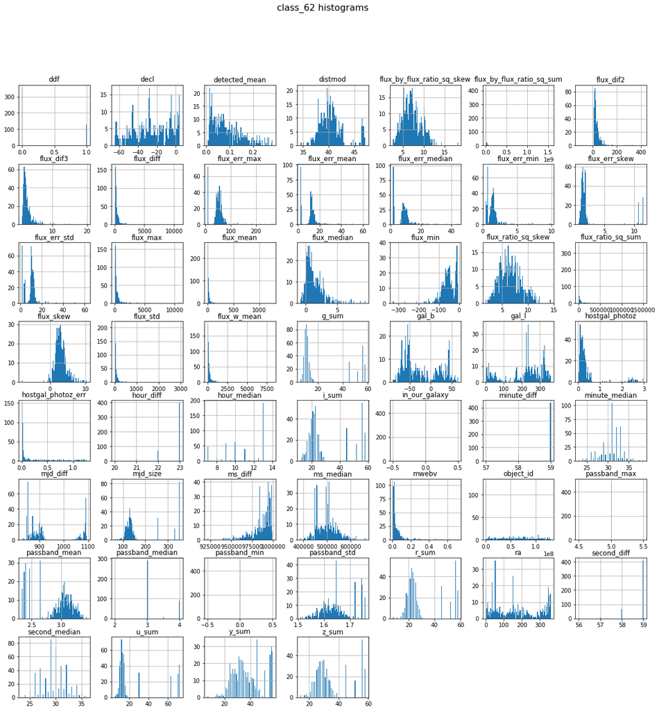

[2 more figures not shown]

```python
# histograms per class
targets = set(training_dataset['target'])
for target in targets:
    fig = plt.figure(figsize=(20,20))
    ax = fig.add_subplot(111)
    training_dataset[training_dataset['target'].str.contains(target)].hist(bins=100, ax=ax)
    fig.suptitle('{} histograms'.format(target), fontsize=16)
```

# Prepare training data and labels

```python
# separate labels
Y = training_dataset['target']
Y.head()
```

```
0    class_92
1    class_88
2    class_42
3    class_90
4    class_90
Name: target, dtype: object
```

```python
# separate training values (exclude labels and object_id)
X = training_dataset.drop(['target', 'object_id'], axis=1)
X.head()
```

|  | flux_min | flux_max | flux_mean | flux_median | flux_std | flux_skew | second_median | g_sum | detected_mean | hour_median | ... | ra | decl | gal_l | gal_b | ddf | hostgal_photoz | hostgal_photoz_err | distmod | mwebv | in_our_galaxy |
| --- | --- | --- | --- | --- | --- | --- | --- | --- | --- | --- | --- | --- | --- | --- | --- | --- | --- | --- | --- | --- | --- |
| 0 | -1100.440063 | 660.626343 | -123.096998 | -89.477524 | 394.109851 | -0.349540 | 30.0 | 58 | 0.946023 | 13.0 | ... | 349.046051 | -61.943836 | 320.796530 | -51.753706 | 1 | 0.0000 | 0.0000 | 0.0000 | 0.017 | 1 |
| 1 | -14.735178 | 14.770886 | -1.423351 | -0.873033 | 6.471144 | 0.014989 | 27.0 | 56 | 0.171429 | 7.0 | ... | 53.085938 | -27.784405 | 223.525509 | -54.460748 | 1 | 1.6267 | 0.2552 | 45.4063 | 0.007 | 0 |
| 2 | -19.159811 | 47.310059 | 2.267434 | 0.409172 | 8.022239 | 3.177854 | 32.0 | 52 | 0.069697 | 7.0 | ... | 33.574219 | -6.579593 | 170.455585 | -61.548219 | 1 | 0.2262 | 0.0157 | 40.2561 | 0.021 | 0 |
| 3 | -15.494463 | 220.795212 | 8.909206 | 1.035895 | 27.558208 | 4.979826 | 26.0 | 56 | 0.173789 | 13.0 | ... | 0.189873 | -45.586655 | 328.254458 | -68.969298 | 1 | 0.2813 | 1.1523 | 40.7951 | 0.007 | 0 |
| 4 | -16.543753 | 143.600189 | 7.145702 | 1.141288 | 20.051722 | 4.406298 | 30.0 | 58 | 0.173295 | 13.0 | ... | 352.711273 | -63.823658 | 316.922299 | -51.059403 | 1 | 0.2415 | 0.0176 | 40.4166 | 0.024 | 0 |

5 rows × 52 columns

# Cross Validation each algorithm

CV=5 -> compute scores 5 times per algorithm with random state

```python
from sklearn.linear_model import LogisticRegression
from sklearn.tree import DecisionTreeClassifier
from sklearn.neighbors import KNeighborsClassifier
from sklearn.discriminant_analysis import LinearDiscriminantAnalysis
from sklearn.naive_bayes import GaussianNB
from sklearn.svm import SVC
from sklearn.ensemble import AdaBoostClassifier
from sklearn.ensemble import GradientBoostingClassifier
from sklearn.ensemble import RandomForestClassifier
from sklearn.ensemble import ExtraTreesClassifier
from xgboost import XGBClassifier
from lightgbm import LGBMClassifier
from sklearn.model_selection import cross_val_score
from sklearn.pipeline import make_pipeline
import time
models = {"LogisticRegression": LogisticRegression(), "DecisionTreeClassifier": DecisionTreeClassifier(),
          "KNeighborsClassifier": KNeighborsClassifier(), "LinearDiscriminantAnalysis": LinearDiscriminantAnalysis(),
          "GaussianNB": GaussianNB(), "SVC": SVC(probability=True), "AdaBoostClassifier": AdaBoostClassifier(),
          "GradientBoostingClassifier": GradientBoostingClassifier(), "RandomForestClassifier": RandomForestClassifier(),
          "ExtraTreesClassifier": ExtraTreesClassifier(), "XGBClassifier": XGBClassifier(), "LGBMClassifier": LGBMClassifier()}
models_score = pd.DataFrame(columns=["Model", "Mean", "Std", "Time"], data=np.zeros((len(models),4)))
for i, (name, model) in enumerate(models.items()):
    clf = make_pipeline(StandardScaler(), model)
    # perform cross validation (compute mean and std from 5 random treinings and predictions per algorithm)
    # scoring -> neg_log_loss (closer to 0 is better)
    # explenation of log_loss
    # https://stackoverflow.com/questions/35013822/log-loss-output-is-greater-than-1
    start = time.time()
    scores = cross_val_score(clf, X.values, Y, cv=5, scoring="neg_log_loss")
    end = time.time()
    print("Log Loss: {:0.2f} (+/- {:0.2f}) Model: {} Elapsed time: {}".format(scores.mean(), scores.std() * 2, name, end-start))
    # store results in dataframe
    models_score["Model"][i] = name
    models_score["Mean"][i] = scores.mean()
    models_score["Std"][i] = scores.std()
    models_score["Time"][i] = end-start
```

```
Log Loss: -1.11 (+/- 0.11) Model: LogisticRegression Elapsed time: 13.523458242416382
Log Loss: -1.13 (+/- 0.29) Model: SVC Elapsed time: 72.40939736366272
Log Loss: -12.58 (+/- 5.21) Model: GaussianNB Elapsed time: 0.28937244415283203
Log Loss: -8.68 (+/- 3.52) Model: KNeighborsClassifier Elapsed time: 3.983812093734741
Log Loss: -2.02 (+/- 0.00) Model: LinearDiscriminantAnalysis Elapsed time: 0.5558404922485352
Log Loss: -0.87 (+/- 0.06) Model: XGBClassifier Elapsed time: 80.04815411567688
Log Loss: -0.90 (+/- 0.07) Model: LGBMClassifier Elapsed time: 24.492074012756348
Log Loss: -14.44 (+/- 1.17) Model: DecisionTreeClassifier Elapsed time: 2.0460832118988037
Log Loss: -4.27 (+/- 3.31) Model: ExtraTreesClassifier Elapsed time: 0.8186759948730469
Log Loss: -3.59 (+/- 0.78) Model: RandomForestClassifier Elapsed time: 1.828111171722412
Log Loss: -1.85 (+/- 0.20) Model: AdaBoostClassifier Elapsed time: 10.512624025344849
Log Loss: -0.90 (+/- 0.05) Model: GradientBoostingClassifier Elapsed time: 156.41159415245056
```

```python
models_score.to_csv("..\\models_score_logloss_cv5_complete.csv")
```

# Each model mean score with std and computing time (without additional features)

Log Loss: -7.88 (+/- 2.08) Model: ExtraTreesClassifier Elapsed time: 100.08285164833069  
Log Loss: -1.85 (+/- 0.15) Model: LinearDiscriminantAnalysis Elapsed time: 61.01738452911377  
Log Loss: -1.25 (+/- 0.10) Model: XGBClassifier Elapsed time: 6123.167793512344  
Log Loss: -6.99 (+/- 1.44) Model: RandomForestClassifier Elapsed time: 198.34502911567688  
Log Loss: -20.88 (+/- 2.90) Model: DecisionTreeClassifier Elapsed time: 113.53170943260193  
Log Loss: -1.29 (+/- 0.08) Model: GradientBoostingClassifier Elapsed time: 13707.762514591217  
Log Loss: -2.09 (+/- 0.37) Model: AdaBoostClassifier Elapsed time: 1149.7346422672272  
Log Loss: -17.01 (+/- 1.61) Model: KNeighborsClassifier Elapsed time: 4172.4097192287445  
Log Loss: -2.89 (+/- 0.83) Model: GaussianNB Elapsed time: 48.0736665725708  
Log Loss: -1.54 (+/- 0.14) Model: LogisticRegression Elapsed time: 1171.7033350467682

# Each model mean score with std and computing time (with additional features)

Log Loss: -9.08 (+/- 3.65) Model: KNeighborsClassifier Elapsed time: 2.445700168609619  
Log Loss: -3.97 (+/- 1.75) Model: ExtraTreesClassifier Elapsed time: 0.700063943862915  
Log Loss: -0.87 (+/- 0.06) Model: XGBClassifier Elapsed time: 64.45711851119995  
Log Loss: -3.61 (+/- 1.10) Model: RandomForestClassifier Elapsed time: 1.710193395614624  
Log Loss: -1.85 (+/- 0.20) Model: AdaBoostClassifier Elapsed time: 9.25883936882019  
Log Loss: -1.67 (+/- 0.16) Model: LinearDiscriminantAnalysis Elapsed time: 0.3839569091796875  
Log Loss: -0.90 (+/- 0.07) Model: LGBMClassifier Elapsed time: 23.777573823928833  
Log Loss: -14.06 (+/- 1.10) Model: DecisionTreeClassifier Elapsed time: 2.099644660949707  
Log Loss: -11.23 (+/- 4.38) Model: GaussianNB Elapsed time: 0.2790977954864502  
Log Loss: -1.28 (+/- 0.11) Model: LogisticRegression Elapsed time: 8.399703025817871  
Log Loss: -0.89 (+/- 0.05) Model: GradientBoostingClassifier Elapsed time: 136.06629729270935  
Log Loss: -1.17 (+/- 0.28) Model: SVC Elapsed time: 57.43256688117981

# new features - our_galaxy, distmod, u,i,g,r,z,y

Log Loss: -1.11 (+/- 0.11) Model: LogisticRegression Elapsed time: 13.523458242416382  
Log Loss: -1.13 (+/- 0.29) Model: SVC Elapsed time: 72.40939736366272  
Log Loss: -12.58 (+/- 5.21) Model: GaussianNB Elapsed time: 0.28937244415283203  
Log Loss: -8.68 (+/- 3.52) Model: KNeighborsClassifier Elapsed time: 3.983812093734741  
Log Loss: -2.02 (+/- 0.00) Model: LinearDiscriminantAnalysis Elapsed time: 0.5558404922485352  
Log Loss: -0.87 (+/- 0.06) Model: XGBClassifier Elapsed time: 80.04815411567688  
Log Loss: -0.90 (+/- 0.07) Model: LGBMClassifier Elapsed time: 24.492074012756348  
Log Loss: -14.44 (+/- 1.17) Model: DecisionTreeClassifier Elapsed time: 2.0460832118988037  
Log Loss: -4.27 (+/- 3.31) Model: ExtraTreesClassifier Elapsed time: 0.8186759948730469  
Log Loss: -3.59 (+/- 0.78) Model: RandomForestClassifier Elapsed time: 1.828111171722412  
Log Loss: -1.85 (+/- 0.20) Model: AdaBoostClassifier Elapsed time: 10.512624025344849  
Log Loss: -0.90 (+/- 0.05) Model: GradientBoostingClassifier Elapsed time: 156.41159415245056

# What need to be done:

- use GridSearch for best performing algorithms to tune hyperparameters